# Relatório Atividade Prática 3

Grupo 5

#### Integrantes do Grupo:

- Bruno Marcelino
- Daniel Rocha
- David Alexsander
- Felipe Robadel
- Gabriela Lamas

# Introdução e Tratamento dos Dados

Usaremos o conjunto de pacotes `"tidyverse"` para realizar algumas operações, sobretudo utilizando recursos gráficos.

```r
# ---- Importação das Bibliotecas ----
library("tidyverse")
library("tidyquant")
library("Quandl")
library("timetk")
library("devtools")
library("quantmod")
library("readxl")
library("GetQuandlData")
library("AER")
library("strucchange")
```

```r
# ---- Importação dos Dados ----

# Cotações
ativos <- c("VALE3.SA", "^BVSP")
inicio <- as.Date("2010-01-04")
fim <- as.Date("2020-12-30")

cotacao <- ativos %>%
    tq_get(get = "stock.prices", from = inicio, to = fim) %>%
    mutate(adjusted = na.locf(adjusted))

# Retornos

df_retornos <- cotacao %>%
    group_by(symbol) %>%
    select(date, adjusted) %>%
    tq_transmute(select = adjusted,
                 mutate_fun = periodReturn,
                 period = "daily",
                 type = "arithmetic",
                 col_rename = "retorno") %>%
    spread(key = symbol, value = retorno)

# ---- Importando a taxa SELIC da API do BACEN (de 2010 até hoje) ----

Quandl.api_key('TC1ow5j6G7s4SFHTzgDz') # Acrescentando a chave da API - Comando necessário pra acessar o Quandl
selic_diaria <-  as.data.frame(Quandl("BCB/11", type = "xts")/100) # Importando a serie do selic do Bacen
df_selic <- selic_diaria %>%
    rownames_to_column() %>%
    tibble() %>%
    rename("date" = rowname, "selic" = V1) %>%
    mutate(selic = na.locf(selic))

df_selic$date <- as.Date(df_selic$date)

# acréscimo na base de dados
df_retornos <- df_retornos %>%
    left_join(df_selic, by = "date")
```

# Respostas

```r
# ---- Montando regressão do CAPM ----
df_capm <- df_retornos %>%
    transmute("date" = date, "Rp-Rf" = VALE3.SA - selic, "Rm-Rf" = `^BVSP` - selic)

capm1 <- lm(df_capm$`Rp-Rf` ~ df_capm$`Rm-Rf`)
summary(capm1)
```

```
##
## Call:
## lm(formula = df_capm$`Rp-Rf` ~ df_capm$`Rm-Rf`)
##
## Residuals:
##       Min        1Q    Median        3Q       Max
## -0.221788 -0.010506 -0.000482  0.010061  0.114321
##
## Coefficients:
##                  Estimate Std. Error t value Pr(>|t|)
## (Intercept)     0.0003861  0.0003984   0.969    0.332
## df_capm$`Rm-Rf` 1.0575159  0.0250509  42.215   <2e-16 ***
## ---
## Signif. codes:  0 '***' 0.001 '**' 0.01 '*' 0.05 '.' 0.1 ' ' 1
##
## Residual standard error: 0.02078 on 2719 degrees of freedom
##   (6 observations deleted due to missingness)
## Multiple R-squared:  0.3959, Adjusted R-squared:  0.3957
## F-statistic:  1782 on 1 and 2719 DF,  p-value: < 2.2e-16
```

```r
# ---- Montando regressão de Fama-French ----

# (adaptar os arquivos diretamente no Excel, manipulando a data para o formato YYYY-MM-DD)
# Posso usar a função as.Date(paste(year, month, day, sep = "-")) também
MKT_Factor <- read_excel("D:/Dropbox/UFMG/Programação/R/Métodos/Ativ Prát 3/Market_Factor.xls")
```

```
## * `` -> ...6
```

```r
HML_Factor <- read_excel("D:/Dropbox/UFMG/Programação/R/Métodos/Ativ Prát 3/HML_Factor.xls")
```

```
## * `` -> ...6
```

```r
SMB_Factor <- read_excel("D:/Dropbox/UFMG/Programação/R/Métodos/Ativ Prát 3/SMB_Factor.xls")
```

```
## * `` -> ...6
```

```r
HML <- HML_Factor %>% select(date, HML)
HML$date <- as.Date(HML$date)

MKT <- MKT_Factor %>% select(date, Rm_minus_Rf) %>% rename("MKT" = Rm_minus_Rf)
MKT$date <- as.Date(MKT$date)

SMB <- SMB_Factor %>% select(date, SMB)
SMB$date <- as.Date(SMB$date)
```

#### QUESTÃO 1:

Montando gráfico com os retornos da ação escolhida

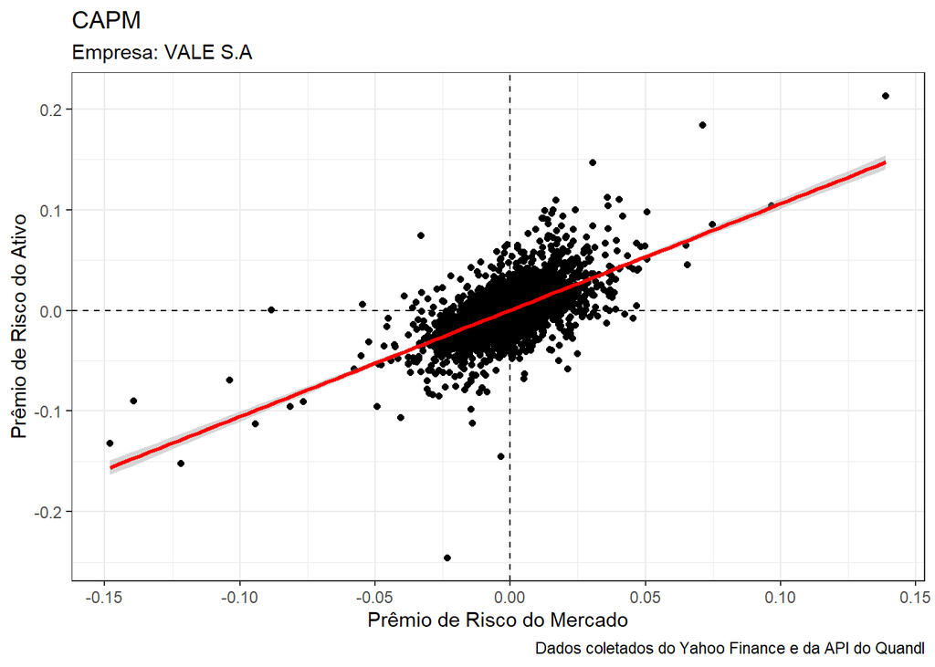

```r
# Gráfico CAPM

graf_1 <- df_capm %>%
    ggplot(aes(x = `Rm-Rf`, y = `Rp-Rf`)) +
    geom_point() +
    labs(x = "Prêmio de Risco do Mercado",
         y = "Prêmio de Risco do Ativo",
         title = "CAPM",
         subtitle = "Empresa: VALE S.A",
         caption = "Dados coletados do Yahoo Finance e da API do Quandl") +
    geom_hline(yintercept = 0, linetype = "dashed") +
    geom_vline(xintercept = 0, linetype = "dashed") +
    geom_smooth(method = "lm", color = "red") +
    theme_bw()

graf_1
```

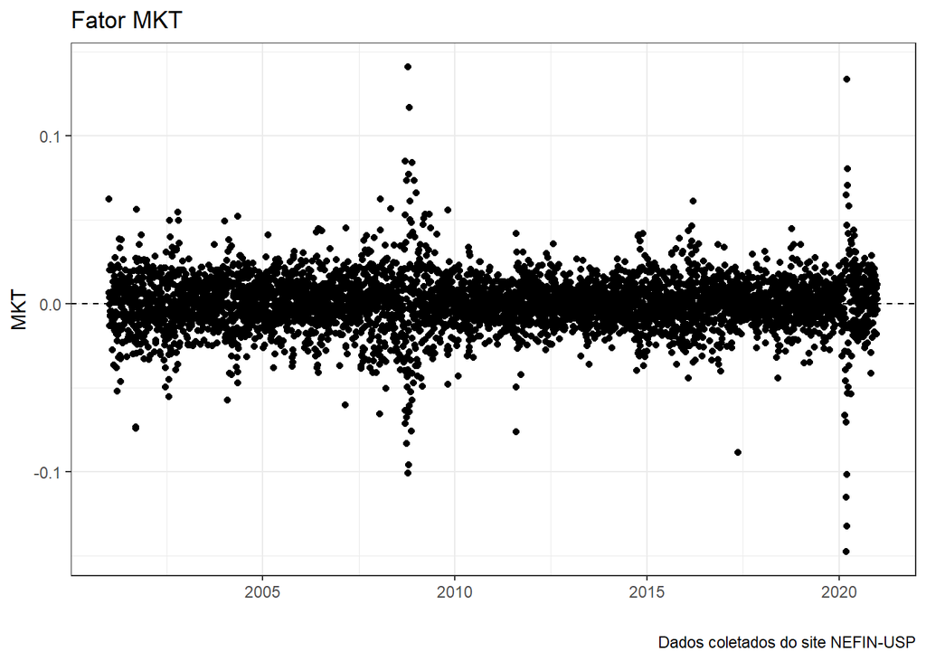

```r
graf_2 <- MKT %>%
    ggplot(aes(x = date, y = MKT)) +
    geom_point() +
    labs(x = "",
         y = "MKT",
         title = "Fator MKT",
         caption = "Dados coletados do site NEFIN-USP") +
    geom_hline(yintercept = 0, linetype = "dashed") +
    theme_bw()

graf_2
```

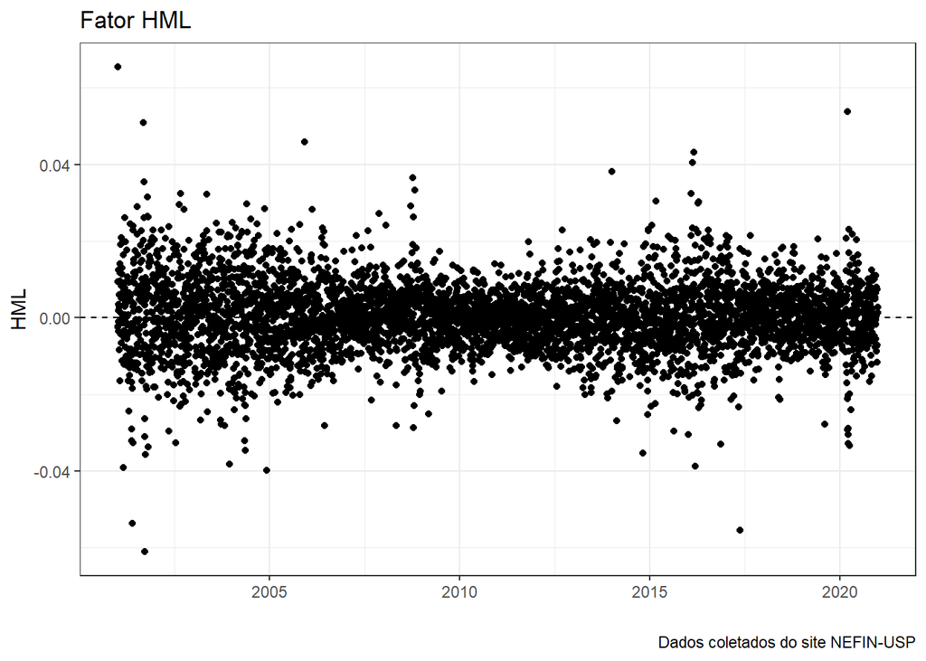

```r
graf_3 <- HML %>%
    ggplot(aes(x = date, y = HML)) +
    geom_point() +
    labs(x = "",
         y = "HML",
         title = "Fator HML",
         caption = "Dados coletados do site NEFIN-USP") +
    geom_hline(yintercept = 0, linetype = "dashed") +
    theme_bw()

graf_3
```

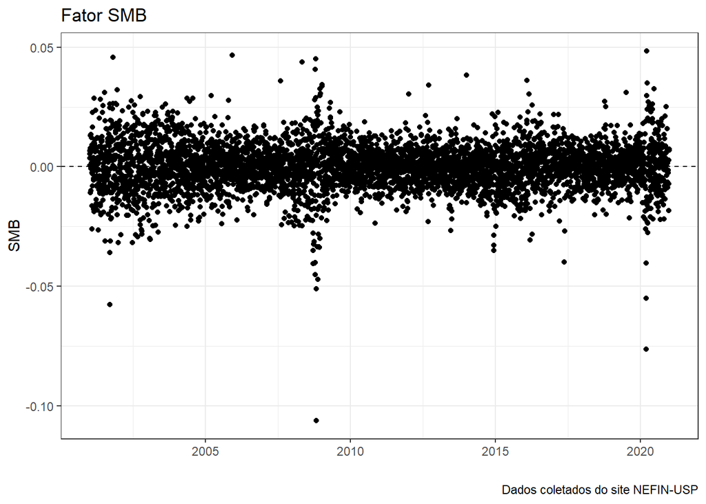

```r
graf_4<- SMB %>%
    ggplot(aes(x = date, y = SMB)) +
    geom_point() +
    labs(x = "",
         y = "SMB",
         title = "Fator SMB",
         caption = "Dados coletados do site NEFIN-USP") +
    geom_hline(yintercept = 0, linetype = "dashed") +
    theme_bw()

graf_4
```

[figure not shown]

```r
SMB <- SMB_Factor %>% select(date, SMB)
SMB$date <- as.Date(SMB$date)

# Gráfico Retornos

graf_5 <- df_retornos %>%
    ggplot(aes(x = date, y = VALE3.SA)) +
    geom_line() +
    geom_hline(yintercept = 0, linetype = "dashed") +
    scale_y_continuous(labels = scales::percent) +
    labs(title = "Retornos Mensais",
         subtitle = "Empresa: Petrobrás S.A",
         y = "Retornos Mensais",
         x = "") +
    theme_tq() +
    scale_fill_tq()

graf_5
```

```r
# ---- Montando regressão de três fatores de Fama-French ----
fatores <- df_capm %>%
    left_join(HML, by = "date") %>%
    left_join(SMB, by = "date") %>%
    left_join(MKT, by = "date") %>%
    select(-`Rm-Rf`)

ffrench1 <- lm(`Rp-Rf` ~ MKT + HML + SMB, data = fatores)
summary(ffrench1)
```

```
##
## Call:
## lm(formula = `Rp-Rf` ~ MKT + HML + SMB, data = fatores)
##
## Residuals:
##       Min        1Q    Median        3Q       Max
## -0.230727 -0.010458 -0.000377  0.009973  0.133559
##
## Coefficients:
##               Estimate Std. Error t value Pr(>|t|)
## (Intercept)  0.0002043  0.0003985   0.513    0.608
## MKT          0.9891821  0.0294863  33.547  < 2e-16 ***
## HML          0.7747221  0.0552075  14.033  < 2e-16 ***
## SMB         -0.4048052  0.0507951  -7.969 2.33e-15 ***
## ---
## Signif. codes:  0 '***' 0.001 '**' 0.01 '*' 0.05 '.' 0.1 ' ' 1
##
## Residual standard error: 0.02077 on 2714 degrees of freedom
##   (9 observations deleted due to missingness)
## Multiple R-squared:  0.3975, Adjusted R-squared:  0.3968
## F-statistic: 596.8 on 3 and 2714 DF,  p-value: < 2.2e-16
```

#### QUESTÃO 2:

```r
# Teste F entre os dois modelos
anova(capm1,ffrench1)
```

[output not shown]

#### QUESTÃO 3:

Valores médios para VIF superiores a 5 s?o um indício de multicolinearidade, sendo assim não há multicolineariade nos testes pois todos os valores são menores que 5.

```r
# VIF do modelo Fama-French
vif(ffrench1)
```

```
##      MKT      HML      SMB
## 1.101118 1.221621 1.141517
```

#### QUESTÃO 4:

Foi obtido estatísticas de teste altas, de forma que o p-valor foi significativo para os dois modelos. Isso indica que há uma forma funcional ou especificação alternativa que melhor valide o modelo. Fazendo o teste para os regressores também identificamos p-valores significativos, onde devemos verificar se as variáveis independentes são melhores ajustadas ao modelo se tratadas de forma polinomial.

```r
# Teste RESET em cada modelo

resettest(capm1, power = c(2,3,4))
```

```
##
##  RESET test
##
## data:  capm1
## RESET = 6.546, df1 = 3, df2 = 2716, p-value = 0.0002083
```

```r
resettest(ffrench1, power = c(2,3,4))
```

```
##
##  RESET test
##
## data:  ffrench1
## RESET = 7.1495, df1 = 3, df2 = 2711, p-value = 8.828e-05
```

```r
# Avalia o teste como potências dos regressores, e não potências de todas as variáveis em conjunto

resettest(ffrench1, power = c(2,3,4), type = "regressor")
```

```
##
##  RESET test
##
## data:  ffrench1
## RESET = 6.7568, df1 = 9, df2 = 2705, p-value = 1.218e-09
```